# Introduction to Statistical Learning Chapter 8 Problem 8

Robert Smith

8/6/2017

# Exercises

## Applied

8. In the lab, a classification tree was applied to the `Carseats` data set after converting `Sales` into a qualitative response variable. Now we will seek to predict `Sales` using regression trees and related approchaes, treating the response as a quantitative variable.
1. Split the data into a training set and test set.

```r
library(ISLR)
data(Carseats)

set.seed(1234)
nobs<-nrow(Carseats)
train_obs<-sample(1:nobs,nobs*.5)
train_set<-Carseats[train_obs,]
test_set<-Carseats[-train_obs,]
```

2. Fit a regression tree to the training set. Plot the tree, and interpret the results. What test MSE do you obtain?

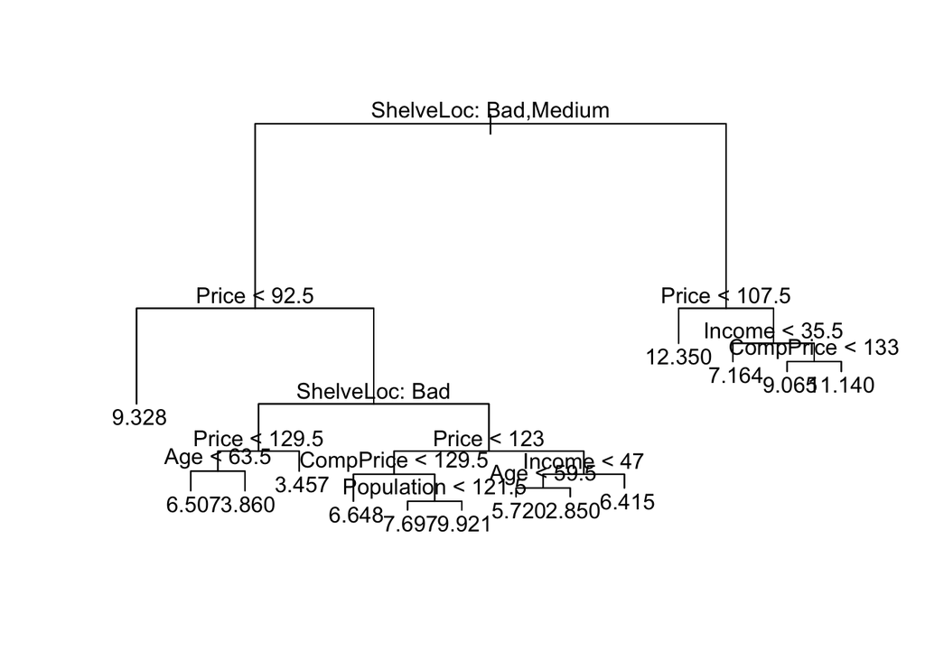

```r
library(tree)
tree_model<-tree(Sales~.,data=train_set)
plot(tree_model)
text(tree_model,pretty=0)
```

Similar results are obtained compared to the tree lab. The main factor in determinine carseat sales is shelf location, followed by price.

```r
pred<-predict(tree_model,test_set)
MSE<-mean((test_set$Sales-pred)^2)
print(paste("Test MSE:",round(MSE,3),sep=" "))
```

```
## [1] "Test MSE: 4.924"
```

3. Use cross-validation in order to determine the optimal level of tree complexity. Does pruning the tree improve the test MSE?

```r
set.seed(1)
cv.tree_model<-cv.tree(tree_model)
cv.tree_model
```

```
## $size
##  [1] 14 13 12 11 10  9  8  7  5  4  3  2  1
##
## $dev
##  [1]  997.0010  975.1966  967.5321  950.0182  948.8645  991.8761 1013.7846
##  [8] 1004.9467 1018.0403 1092.5358 1155.2083 1266.0365 1637.4231
##
## $k
##  [1]      -Inf  20.36399  20.59225  23.37218  32.41251  42.88010  45.91815
##  [8]  47.11525  58.97569  82.36767 111.11409 224.87352 434.32339
##
## $method
## [1] "deviance"
##
## attr(,"class")
## [1] "prune"         "tree.sequence"
```

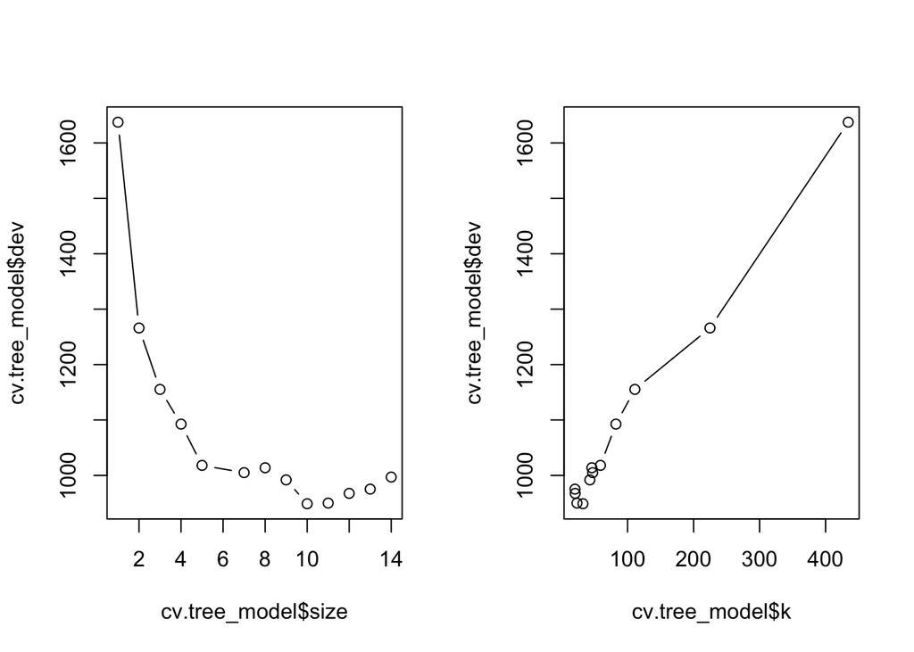

```r
par(mfrow=c(1,2))
plot(cv.tree_model$size,cv.tree_model$dev,type="b")
plot(cv.tree_model$k,cv.tree_model$dev,type="b")
```

Lowest cross-validated error corresponds to a tree with 10 nodes.

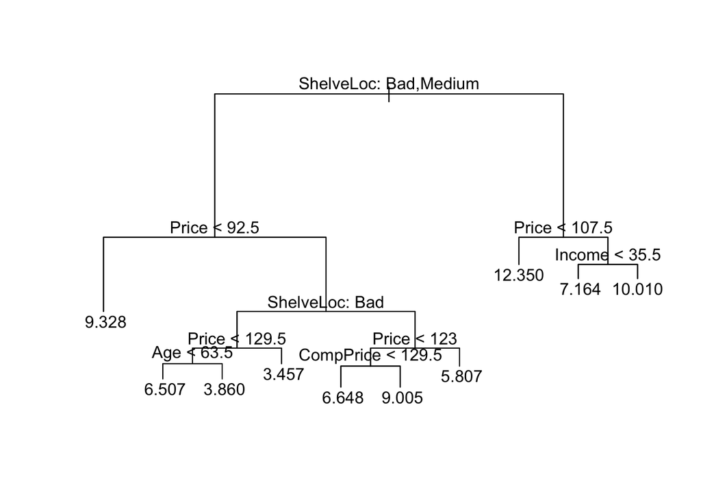

```r
prune.cv.tree_model<-prune.tree(tree_model,best=10)
plot(prune.cv.tree_model)
text(prune.cv.tree_model,pretty=0)
```

Predict test MSE on pruned tree:

```r
pred<-predict(prune.cv.tree_model,test_set)
MSE<-mean((test_set$Sales-pred)^2)
print(paste("Cross-Validated Test MSE:",round(MSE,3),sep=" "))
```

```
## [1] "Cross-Validated Test MSE: 4.863"
```

Pruning did marginally reduce the test MSE.

4. Use the bagging apprach in order to analyze this data. What test MSE do you obtain? Use the `importance()` function to determine which variables are most important.

Recall that bagging is just a special case of Random Forest where all predictors are considered at each split:

```r
library(randomForest)
set.seed(1234)
bag.tree_model<-randomForest(Sales~.,data=train_set,mtry=10,importance=T)
bag.tree_model
```

```
##
## Call:
##  randomForest(formula = Sales ~ ., data = train_set, mtry = 10,      importance = T)
##                Type of random forest: regression
##                      Number of trees: 500
## No. of variables tried at each split: 10
##
##           Mean of squared residuals: 2.642448
##                     % Var explained: 67.12
```

```r
pred<-predict(bag.tree_model,test_set)
MSE<-mean((test_set$Sales-pred)^2)
print(paste("Bagged Test MSE:",round(MSE,3),sep=" "))
```

```
## [1] "Bagged Test MSE: 2.979"
```

```r
importance(bag.tree_model)
```

```
##                 %IncMSE IncNodePurity
## CompPrice   21.95539712    147.614280
## Income       9.45305153     86.806688
## Advertising 11.09296217     90.488192
## Population   0.49750613     73.136918
## Price       59.47574652    485.412064
## ShelveLoc   63.50419478    520.758482
## Age          6.61343677    100.248003
## Education   -0.06603699     38.949527
## Urban        0.59874097      7.574255
## US           0.49019005      4.879805
```

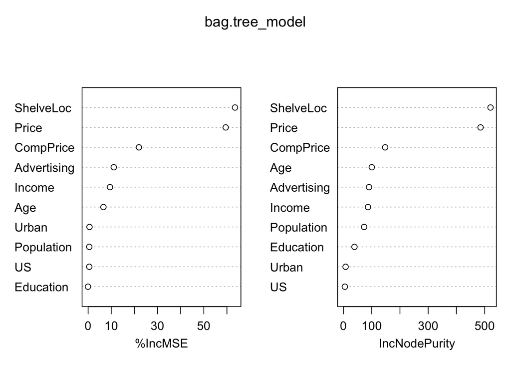

```r
varImpPlot(bag.tree_model)
```

The test MSE is reducted by approximately 40%. As indicated by the variable importance graphs, the most important variables for prediction are carseat price and shelf location.

5. Use random forests to analyze this data. What test MSE do you obtain? Use the `importance` function to determine which variables are most important. Describe the effect of *m*, the number of variables considered at each split, on the error rate obtained.

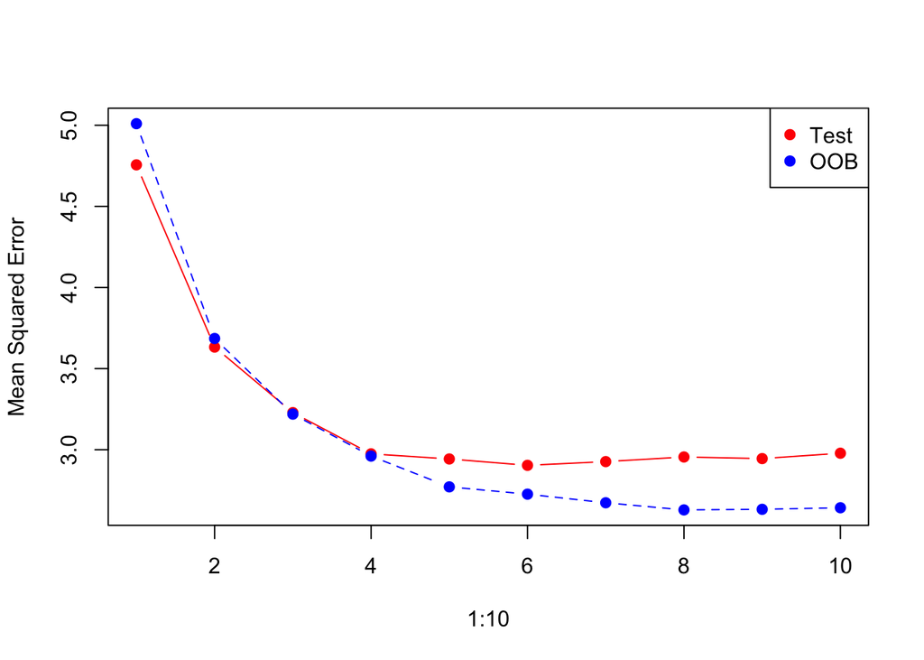

```r
MSE_List<-rep(NA,10)
OOB_List<-rep(NA,10)
for (i in 1:10){
set.seed(1234)
bag.tree_model<-randomForest(Sales~.,data=train_set,mtry=i,importance=T)
OOB_List[i]<-bag.tree_model$mse[500]
pred<-predict(bag.tree_model,test_set)
MSE_List[i]<-mean((test_set$Sales-pred)^2)
}
matplot(1:10,cbind(MSE_List,OOB_List),pch=19,col=c("red","blue"),type="b",ylab="Mean Squared Error")
legend("topright",legend=c("Test","OOB"),pch=19,col=c("red","blue"))
```

Based on the plot, it appears that the consideration of 6 variables at each split minimizes the test MSE:

```r
final.bag.tree_model<-randomForest(Sales~.,data=train_set,mtry=6,importance=T)
importance(final.bag.tree_model)
```

```
##                %IncMSE IncNodePurity
## CompPrice   16.6252321    140.368788
## Income       6.5061794    103.790791
## Advertising 11.8307123    108.373476
## Population   0.0674609     82.438332
## Price       51.4876630    456.140003
## ShelveLoc   53.8934453    465.077943
## Age          9.4135548    122.925129
## Education    2.0942415     47.096684
## Urban       -2.7213017      8.997998
## US          -1.7727416      6.894806
```

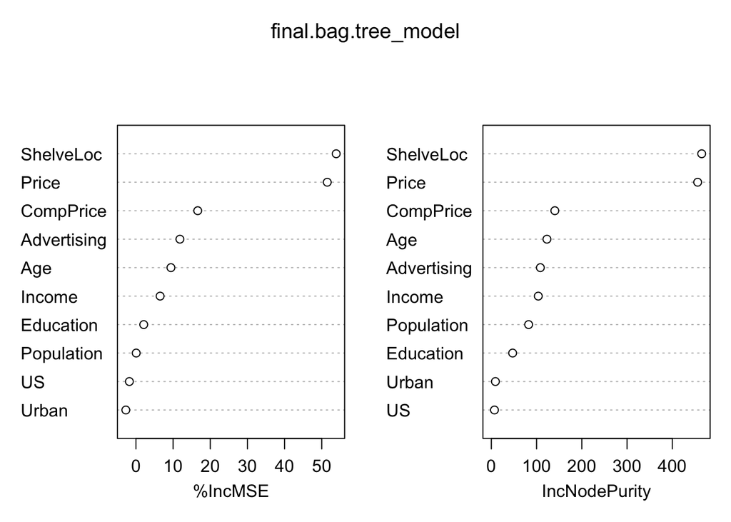

```r
varImpPlot(final.bag.tree_model)
```